# Risk Factor Analysis

## Outcome Variable

**Outcome Variable:** sstunted

## Predictor Variables

**Intervention Variable:** mage

**Adjustment Set:**

unadjusted

## Stratifying Variables

The analysis was stratified on these variable(s):

- agecat
- studyid
- country

## Data Summary

| agecat | studyid | country | mage | sstunted | n_cell | n |
| --- | --- | --- | --- | --- | --- | --- |
| Birth | CMC-V-BCS-2002 | INDIA | [20-30) | 0 | 77 | 92 |
| Birth | CMC-V-BCS-2002 | INDIA | [20-30) | 1 | 2 | 92 |
| Birth | CMC-V-BCS-2002 | INDIA | <20 | 0 | 7 | 92 |
| Birth | CMC-V-BCS-2002 | INDIA | <20 | 1 | 2 | 92 |
| Birth | CMC-V-BCS-2002 | INDIA | >=30 | 0 | 4 | 92 |
| Birth | CMC-V-BCS-2002 | INDIA | >=30 | 1 | 0 | 92 |
| Birth | COHORTS | GUATEMALA | [20-30) | 0 | 400 | 852 |
| Birth | COHORTS | GUATEMALA | [20-30) | 1 | 5 | 852 |
| Birth | COHORTS | GUATEMALA | <20 | 0 | 120 | 852 |
| Birth | COHORTS | GUATEMALA | <20 | 1 | 1 | 852 |
| Birth | COHORTS | GUATEMALA | >=30 | 0 | 321 | 852 |
| Birth | COHORTS | GUATEMALA | >=30 | 1 | 5 | 852 |
| Birth | COHORTS | INDIA | [20-30) | 0 | 3087 | 4715 |
| Birth | COHORTS | INDIA | [20-30) | 1 | 93 | 4715 |
| Birth | COHORTS | INDIA | <20 | 0 | 352 | 4715 |
| Birth | COHORTS | INDIA | <20 | 1 | 16 | 4715 |
| Birth | COHORTS | INDIA | >=30 | 0 | 1138 | 4715 |
| Birth | COHORTS | INDIA | >=30 | 1 | 29 | 4715 |
| Birth | COHORTS | PHILIPPINES | [20-30) | 0 | 1802 | 3050 |
| Birth | COHORTS | PHILIPPINES | [20-30) | 1 | 19 | 3050 |
| Birth | COHORTS | PHILIPPINES | <20 | 0 | 368 | 3050 |
| Birth | COHORTS | PHILIPPINES | <20 | 1 | 10 | 3050 |
| Birth | COHORTS | PHILIPPINES | >=30 | 0 | 834 | 3050 |
| Birth | COHORTS | PHILIPPINES | >=30 | 1 | 17 | 3050 |
| Birth | EE | PAKISTAN | [20-30) | 0 | 76 | 239 |
| Birth | EE | PAKISTAN | [20-30) | 1 | 18 | 239 |
| Birth | EE | PAKISTAN | <20 | 0 | 1 | 239 |
| Birth | EE | PAKISTAN | <20 | 1 | 0 | 239 |
| Birth | EE | PAKISTAN | >=30 | 0 | 115 | 239 |
| Birth | EE | PAKISTAN | >=30 | 1 | 29 | 239 |

[output cut: 378 more lines]

The following strata were considered:

- agecat: 24 months, studyid: CMC-V-BCS-2002, country: INDIA
- agecat: 24 months, studyid: COHORTS, country: GUATEMALA
- agecat: 24 months, studyid: COHORTS, country: INDIA
- agecat: 24 months, studyid: COHORTS, country: PHILIPPINES
- agecat: 24 months, studyid: EE, country: PAKISTAN
- agecat: 24 months, studyid: GMS-Nepal, country: NEPAL
- agecat: 24 months, studyid: IRC, country: INDIA
- agecat: 24 months, studyid: Keneba, country: GAMBIA
- agecat: 24 months, studyid: LCNI-5, country: MALAWI
- agecat: 24 months, studyid: MAL-ED, country: BANGLADESH
- agecat: 24 months, studyid: MAL-ED, country: BRAZIL
- agecat: 24 months, studyid: MAL-ED, country: INDIA
- agecat: 24 months, studyid: MAL-ED, country: NEPAL
- agecat: 24 months, studyid: MAL-ED, country: PERU
- agecat: 24 months, studyid: MAL-ED, country: SOUTH AFRICA
- agecat: 24 months, studyid: MAL-ED, country: TANZANIA, UNITED REPUBLIC OF
- agecat: 24 months, studyid: NIH-Birth, country: BANGLADESH
- agecat: 24 months, studyid: NIH-Crypto, country: BANGLADESH
- agecat: 24 months, studyid: PROBIT, country: BELARUS
- agecat: 24 months, studyid: PROVIDE, country: BANGLADESH
- agecat: 24 months, studyid: TanzaniaChild2, country: TANZANIA, UNITED REPUBLIC OF
- agecat: 24 months, studyid: ZVITAMBO, country: ZIMBABWE
- agecat: 6 months, studyid: CMC-V-BCS-2002, country: INDIA
- agecat: 6 months, studyid: COHORTS, country: GUATEMALA
- agecat: 6 months, studyid: COHORTS, country: INDIA
- agecat: 6 months, studyid: COHORTS, country: PHILIPPINES
- agecat: 6 months, studyid: EE, country: PAKISTAN
- agecat: 6 months, studyid: GMS-Nepal, country: NEPAL
- agecat: 6 months, studyid: Guatemala BSC, country: GUATEMALA
- agecat: 6 months, studyid: IRC, country: INDIA
- agecat: 6 months, studyid: Keneba, country: GAMBIA
- agecat: 6 months, studyid: LCNI-5, country: MALAWI
- agecat: 6 months, studyid: MAL-ED, country: BANGLADESH
- agecat: 6 months, studyid: MAL-ED, country: BRAZIL
- agecat: 6 months, studyid: MAL-ED, country: INDIA
- agecat: 6 months, studyid: MAL-ED, country: NEPAL
- agecat: 6 months, studyid: MAL-ED, country: PERU
- agecat: 6 months, studyid: MAL-ED, country: SOUTH AFRICA
- agecat: 6 months, studyid: MAL-ED, country: TANZANIA, UNITED REPUBLIC OF
- agecat: 6 months, studyid: NIH-Birth, country: BANGLADESH
- agecat: 6 months, studyid: NIH-Crypto, country: BANGLADESH
- agecat: 6 months, studyid: PROBIT, country: BELARUS
- agecat: 6 months, studyid: PROVIDE, country: BANGLADESH
- agecat: 6 months, studyid: SAS-CompFeed, country: INDIA
- agecat: 6 months, studyid: SAS-FoodSuppl, country: INDIA
- agecat: 6 months, studyid: TanzaniaChild2, country: TANZANIA, UNITED REPUBLIC OF
- agecat: 6 months, studyid: ZVITAMBO, country: ZIMBABWE
- agecat: Birth, studyid: CMC-V-BCS-2002, country: INDIA
- agecat: Birth, studyid: COHORTS, country: GUATEMALA
- agecat: Birth, studyid: COHORTS, country: INDIA
- agecat: Birth, studyid: COHORTS, country: PHILIPPINES
- agecat: Birth, studyid: EE, country: PAKISTAN
- agecat: Birth, studyid: GMS-Nepal, country: NEPAL
- agecat: Birth, studyid: IRC, country: INDIA
- agecat: Birth, studyid: Keneba, country: GAMBIA
- agecat: Birth, studyid: MAL-ED, country: BANGLADESH
- agecat: Birth, studyid: MAL-ED, country: BRAZIL
- agecat: Birth, studyid: MAL-ED, country: INDIA
- agecat: Birth, studyid: MAL-ED, country: NEPAL
- agecat: Birth, studyid: MAL-ED, country: PERU
- agecat: Birth, studyid: MAL-ED, country: SOUTH AFRICA
- agecat: Birth, studyid: MAL-ED, country: TANZANIA, UNITED REPUBLIC OF
- agecat: Birth, studyid: NIH-Birth, country: BANGLADESH
- agecat: Birth, studyid: NIH-Crypto, country: BANGLADESH
- agecat: Birth, studyid: PROBIT, country: BELARUS
- agecat: Birth, studyid: PROVIDE, country: BANGLADESH
- agecat: Birth, studyid: SAS-CompFeed, country: INDIA
- agecat: Birth, studyid: ZVITAMBO, country: ZIMBABWE

### Dropped Strata

Some strata were dropped due to rare outcomes:

- agecat: Birth, studyid: CMC-V-BCS-2002, country: INDIA
- agecat: Birth, studyid: COHORTS, country: GUATEMALA
- agecat: Birth, studyid: EE, country: PAKISTAN
- agecat: Birth, studyid: GMS-Nepal, country: NEPAL
- agecat: Birth, studyid: IRC, country: INDIA
- agecat: Birth, studyid: MAL-ED, country: BANGLADESH
- agecat: Birth, studyid: MAL-ED, country: BRAZIL
- agecat: Birth, studyid: MAL-ED, country: INDIA
- agecat: Birth, studyid: MAL-ED, country: NEPAL
- agecat: Birth, studyid: MAL-ED, country: PERU
- agecat: Birth, studyid: MAL-ED, country: SOUTH AFRICA
- agecat: Birth, studyid: MAL-ED, country: TANZANIA, UNITED REPUBLIC OF
- agecat: Birth, studyid: NIH-Birth, country: BANGLADESH
- agecat: Birth, studyid: NIH-Crypto, country: BANGLADESH
- agecat: Birth, studyid: PROBIT, country: BELARUS
- agecat: Birth, studyid: PROVIDE, country: BANGLADESH
- agecat: 6 months, studyid: CMC-V-BCS-2002, country: INDIA
- agecat: 6 months, studyid: EE, country: PAKISTAN
- agecat: 6 months, studyid: Guatemala BSC, country: GUATEMALA
- agecat: 6 months, studyid: IRC, country: INDIA
- agecat: 6 months, studyid: Keneba, country: GAMBIA
- agecat: 6 months, studyid: LCNI-5, country: MALAWI
- agecat: 6 months, studyid: MAL-ED, country: BANGLADESH
- agecat: 6 months, studyid: MAL-ED, country: BRAZIL
- agecat: 6 months, studyid: MAL-ED, country: INDIA
- agecat: 6 months, studyid: MAL-ED, country: NEPAL
- agecat: 6 months, studyid: MAL-ED, country: PERU
- agecat: 6 months, studyid: MAL-ED, country: SOUTH AFRICA
- agecat: 6 months, studyid: MAL-ED, country: TANZANIA, UNITED REPUBLIC OF
- agecat: 6 months, studyid: NIH-Birth, country: BANGLADESH
- agecat: 6 months, studyid: PROVIDE, country: BANGLADESH
- agecat: 6 months, studyid: TanzaniaChild2, country: TANZANIA, UNITED REPUBLIC OF
- agecat: 24 months, studyid: EE, country: PAKISTAN
- agecat: 24 months, studyid: IRC, country: INDIA
- agecat: 24 months, studyid: MAL-ED, country: BRAZIL
- agecat: 24 months, studyid: MAL-ED, country: INDIA
- agecat: 24 months, studyid: MAL-ED, country: NEPAL
- agecat: 24 months, studyid: MAL-ED, country: PERU
- agecat: 24 months, studyid: MAL-ED, country: SOUTH AFRICA
- agecat: 24 months, studyid: MAL-ED, country: TANZANIA, UNITED REPUBLIC OF
- agecat: 24 months, studyid: NIH-Birth, country: BANGLADESH
- agecat: 24 months, studyid: NIH-Crypto, country: BANGLADESH
- agecat: 24 months, studyid: TanzaniaChild2, country: TANZANIA, UNITED REPUBLIC OF

## Methods Detail

We’re interested in the causal parameters $E[Y_a]$ for all values of $a \in \mathcal{A}$. These parameters represent the mean outcome if, possibly contrary to fact, we intervened to set all units to have $A=a$. Under the randomization and positivity assumptions, these are identified by the statistical parameters $\psi_a=E_W[E_{Y|A,W}(Y|A=a,W)]$. In addition, we’re interested in the mean of $Y$, $E[Y]$ under no intervention (the observed mean). We will estimate these parameters by using SuperLearner to fit the relevant likelihood factors – $E_{Y|A,W}(Y|A=a,W)$ and $p(A=a|W)$, and then updating our likelihood fit using a joint TMLE.

For unadjusted analyses ($W=\{\}$), initial likelihoods were estimated using Lrnr_glm to estimate the simple $E(Y|A)$ and Lrnr_mean to estimate $p(A)$. For adjusted analyses, a small library containing Lrnr_glmnet, Lrnr_xgboost, and Lrnr_mean was used.

Having estimated these parameters, we will then use the delta method to estimate relative risks and attributable risks relative to a prespecified baseline level of $A$.

# Results Detail

## Results Plots

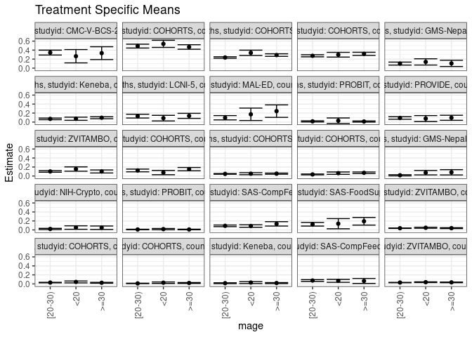

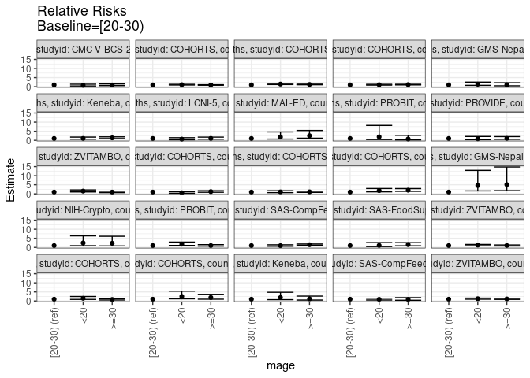

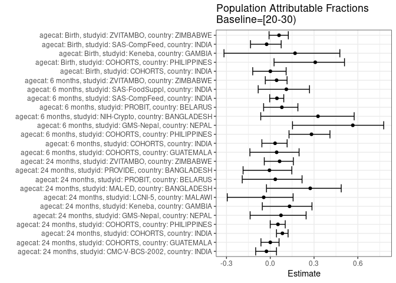

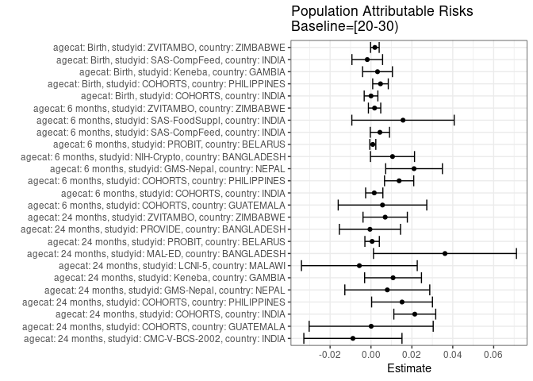

## Results Table

### Parameter: TSM

| agecat | studyid | country | intervention_level | baseline_level | estimate | ci_lower | ci_upper |
| --- | --- | --- | --- | --- | --- | --- | --- |
| Birth | COHORTS | INDIA | [20-30) | NA | 0.0292453 | 0.0233884 | 0.0351021 |
| Birth | COHORTS | INDIA | <20 | NA | 0.0434783 | 0.0226404 | 0.0643162 |
| Birth | COHORTS | INDIA | >=30 | NA | 0.0248500 | 0.0159179 | 0.0337822 |
| Birth | COHORTS | PHILIPPINES | [20-30) | NA | 0.0104338 | 0.0057661 | 0.0151016 |
| Birth | COHORTS | PHILIPPINES | <20 | NA | 0.0264550 | 0.0102740 | 0.0426360 |
| Birth | COHORTS | PHILIPPINES | >=30 | NA | 0.0199765 | 0.0105742 | 0.0293788 |
| Birth | Keneba | GAMBIA | [20-30) | NA | 0.0156028 | 0.0064516 | 0.0247541 |
| Birth | Keneba | GAMBIA | <20 | NA | 0.0294118 | 0.0079395 | 0.0508841 |
| Birth | Keneba | GAMBIA | >=30 | NA | 0.0183333 | 0.0075955 | 0.0290711 |
| Birth | SAS-CompFeed | INDIA | [20-30) | NA | 0.0745016 | 0.0544113 | 0.0945918 |
| Birth | SAS-CompFeed | INDIA | <20 | NA | 0.0683230 | 0.0354638 | 0.1011821 |
| Birth | SAS-CompFeed | INDIA | >=30 | NA | 0.0652174 | 0.0097255 | 0.1207093 |
| Birth | ZVITAMBO | ZIMBABWE | [20-30) | NA | 0.0298957 | 0.0264342 | 0.0333571 |
| Birth | ZVITAMBO | ZIMBABWE | <20 | NA | 0.0376417 | 0.0296973 | 0.0455862 |
| Birth | ZVITAMBO | ZIMBABWE | >=30 | NA | 0.0338910 | 0.0265451 | 0.0412370 |
| 6 months | COHORTS | GUATEMALA | [20-30) | NA | 0.1234043 | 0.0936540 | 0.1531545 |
| 6 months | COHORTS | GUATEMALA | <20 | NA | 0.0762712 | 0.0283546 | 0.1241877 |
| 6 months | COHORTS | GUATEMALA | >=30 | NA | 0.1528150 | 0.1162815 | 0.1893486 |
| 6 months | COHORTS | INDIA | [20-30) | NA | 0.0471330 | 0.0399355 | 0.0543305 |
| 6 months | COHORTS | INDIA | <20 | NA | 0.0512129 | 0.0287803 | 0.0736455 |
| 6 months | COHORTS | INDIA | >=30 | NA | 0.0524126 | 0.0398127 | 0.0650126 |
| 6 months | COHORTS | PHILIPPINES | [20-30) | NA | 0.0349781 | 0.0259770 | 0.0439793 |
| 6 months | COHORTS | PHILIPPINES | <20 | NA | 0.0634441 | 0.0371791 | 0.0897091 |
| 6 months | COHORTS | PHILIPPINES | >=30 | NA | 0.0708763 | 0.0528177 | 0.0889349 |
| 6 months | GMS-Nepal | NEPAL | [20-30) | NA | 0.0161725 | 0.0033257 | 0.0290193 |
| 6 months | GMS-Nepal | NEPAL | <20 | NA | 0.0740741 | 0.0246381 | 0.1235100 |
| 6 months | GMS-Nepal | NEPAL | >=30 | NA | 0.0823529 | 0.0238603 | 0.1408456 |
| 6 months | NIH-Crypto | BANGLADESH | [20-30) | NA | 0.0216450 | 0.0083662 | 0.0349238 |
| 6 months | NIH-Crypto | BANGLADESH | <20 | NA | 0.0534351 | 0.0148957 | 0.0919745 |
| 6 months | NIH-Crypto | BANGLADESH | >=30 | NA | 0.0491803 | 0.0107816 | 0.0875791 |
| 6 months | PROBIT | BELARUS | [20-30) | NA | 0.0103393 | 0.0051173 | 0.0155614 |
| 6 months | PROBIT | BELARUS | <20 | NA | 0.0185300 | 0.0049420 | 0.0321179 |
| 6 months | PROBIT | BELARUS | >=30 | NA | 0.0106195 | 0.0046530 | 0.0165859 |
| 6 months | SAS-CompFeed | INDIA | [20-30) | NA | 0.0914454 | 0.0734609 | 0.1094299 |
| 6 months | SAS-CompFeed | INDIA | <20 | NA | 0.0877193 | 0.0592971 | 0.1161415 |
| 6 months | SAS-CompFeed | INDIA | >=30 | NA | 0.1351351 | 0.0869951 | 0.1832751 |
| 6 months | SAS-FoodSuppl | INDIA | [20-30) | NA | 0.1264368 | 0.0860644 | 0.1668091 |
| 6 months | SAS-FoodSuppl | INDIA | <20 | NA | 0.1388889 | 0.0257707 | 0.2520071 |
| 6 months | SAS-FoodSuppl | INDIA | >=30 | NA | 0.1927711 | 0.1077943 | 0.2777479 |
| 6 months | ZVITAMBO | ZIMBABWE | [20-30) | NA | 0.0386894 | 0.0336992 | 0.0436797 |
| 6 months | ZVITAMBO | ZIMBABWE | <20 | NA | 0.0486692 | 0.0370386 | 0.0602998 |
| 6 months | ZVITAMBO | ZIMBABWE | >=30 | NA | 0.0400000 | 0.0303976 | 0.0496024 |
| 24 months | CMC-V-BCS-2002 | INDIA | [20-30) | NA | 0.3457627 | 0.2914152 | 0.4001103 |
| 24 months | CMC-V-BCS-2002 | INDIA | <20 | NA | 0.2647059 | 0.1162125 | 0.4131993 |
| 24 months | CMC-V-BCS-2002 | INDIA | >=30 | NA | 0.3333333 | 0.1905744 | 0.4760923 |
| 24 months | COHORTS | GUATEMALA | [20-30) | NA | 0.4895636 | 0.4468641 | 0.5322630 |
| 24 months | COHORTS | GUATEMALA | <20 | NA | 0.5394737 | 0.4601975 | 0.6187499 |
| 24 months | COHORTS | GUATEMALA | >=30 | NA | 0.4701299 | 0.4202511 | 0.5200086 |
| 24 months | COHORTS | INDIA | [20-30) | NA | 0.2358912 | 0.2191222 | 0.2526602 |
| 24 months | COHORTS | INDIA | <20 | NA | 0.3400810 | 0.2809936 | 0.3991684 |
| 24 months | COHORTS | INDIA | >=30 | NA | 0.2902240 | 0.2618332 | 0.3186149 |
| 24 months | COHORTS | PHILIPPINES | [20-30) | NA | 0.2739726 | 0.2510908 | 0.2968544 |
| 24 months | COHORTS | PHILIPPINES | <20 | NA | 0.2979452 | 0.2454766 | 0.3504138 |
| 24 months | COHORTS | PHILIPPINES | >=30 | NA | 0.3174603 | 0.2827963 | 0.3521243 |
| 24 months | GMS-Nepal | NEPAL | [20-30) | NA | 0.1006289 | 0.0675302 | 0.1337276 |
| 24 months | GMS-Nepal | NEPAL | <20 | NA | 0.1382979 | 0.0684399 | 0.2081558 |
| 24 months | GMS-Nepal | NEPAL | >=30 | NA | 0.1052632 | 0.0361958 | 0.1743305 |
| 24 months | Keneba | GAMBIA | [20-30) | NA | 0.0708861 | 0.0529851 | 0.0887870 |
| 24 months | Keneba | GAMBIA | <20 | NA | 0.0737327 | 0.0389516 | 0.1085138 |
| 24 months | Keneba | GAMBIA | >=30 | NA | 0.0961810 | 0.0744415 | 0.1179206 |
| 24 months | LCNI-5 | MALAWI | [20-30) | NA | 0.1320000 | 0.0899968 | 0.1740032 |
| 24 months | LCNI-5 | MALAWI | <20 | NA | 0.0875000 | 0.0255158 | 0.1494842 |
| 24 months | LCNI-5 | MALAWI | >=30 | NA | 0.1379310 | 0.0817456 | 0.1941165 |
| 24 months | MAL-ED | BANGLADESH | [20-30) | NA | 0.0958904 | 0.0480168 | 0.1437641 |
| 24 months | MAL-ED | BANGLADESH | <20 | NA | 0.1724138 | 0.0346077 | 0.3102199 |
| 24 months | MAL-ED | BANGLADESH | >=30 | NA | 0.2432432 | 0.1046722 | 0.3818143 |
| 24 months | PROBIT | BELARUS | [20-30) | NA | 0.0155548 | 0.0028971 | 0.0282125 |
| 24 months | PROBIT | BELARUS | <20 | NA | 0.0298103 | -0.0317524 | 0.0913730 |
| 24 months | PROBIT | BELARUS | >=30 | NA | 0.0116429 | -0.0005865 | 0.0238724 |
| 24 months | PROVIDE | BANGLADESH | [20-30) | NA | 0.0904645 | 0.0626411 | 0.1182880 |
| 24 months | PROVIDE | BANGLADESH | <20 | NA | 0.0781250 | 0.0123191 | 0.1439309 |
| 24 months | PROVIDE | BANGLADESH | >=30 | NA | 0.0952381 | 0.0390425 | 0.1514336 |
| 24 months | ZVITAMBO | ZIMBABWE | [20-30) | NA | 0.1017257 | 0.0838647 | 0.1195867 |
| 24 months | ZVITAMBO | ZIMBABWE | <20 | NA | 0.1552511 | 0.1072734 | 0.2032289 |
| 24 months | ZVITAMBO | ZIMBABWE | >=30 | NA | 0.1006289 | 0.0675541 | 0.1337038 |

### Parameter: E(Y)

| agecat | studyid | country | intervention_level | baseline_level | estimate | ci_lower | ci_upper |
| --- | --- | --- | --- | --- | --- | --- | --- |
| Birth | COHORTS | INDIA | NA | NA | 0.0292683 | 0.0244566 | 0.0340800 |
| Birth | COHORTS | PHILIPPINES | NA | NA | 0.0150820 | 0.0107558 | 0.0194081 |
| Birth | Keneba | GAMBIA | NA | NA | 0.0187946 | 0.0120166 | 0.0255726 |
| Birth | SAS-CompFeed | INDIA | NA | NA | 0.0726837 | 0.0523147 | 0.0930527 |
| Birth | ZVITAMBO | ZIMBABWE | NA | NA | 0.0318034 | 0.0288793 | 0.0347275 |
| 6 months | COHORTS | GUATEMALA | NA | NA | 0.1290323 | 0.1078261 | 0.1502384 |
| 6 months | COHORTS | INDIA | NA | NA | 0.0487357 | 0.0427089 | 0.0547626 |
| 6 months | COHORTS | PHILIPPINES | NA | NA | 0.0487445 | 0.0406327 | 0.0568562 |
| 6 months | GMS-Nepal | NEPAL | NA | NA | 0.0372340 | 0.0215945 | 0.0528736 |
| 6 months | NIH-Crypto | BANGLADESH | NA | NA | 0.0321678 | 0.0192256 | 0.0451101 |
| 6 months | PROBIT | BELARUS | NA | NA | 0.0112310 | 0.0054733 | 0.0169886 |
| 6 months | SAS-CompFeed | INDIA | NA | NA | 0.0958084 | 0.0774939 | 0.1141229 |
| 6 months | SAS-FoodSuppl | INDIA | NA | NA | 0.1421053 | 0.1069532 | 0.1772573 |
| 6 months | ZVITAMBO | ZIMBABWE | NA | NA | 0.0404484 | 0.0362972 | 0.0445996 |
| 24 months | CMC-V-BCS-2002 | INDIA | NA | NA | 0.3369272 | 0.2887662 | 0.3850883 |
| 24 months | COHORTS | GUATEMALA | NA | NA | 0.4896617 | 0.4596107 | 0.5197126 |
| 24 months | COHORTS | INDIA | NA | NA | 0.2573131 | 0.2432102 | 0.2714161 |
| 24 months | COHORTS | PHILIPPINES | NA | NA | 0.2891616 | 0.2711872 | 0.3071359 |
| 24 months | GMS-Nepal | NEPAL | NA | NA | 0.1086066 | 0.0809724 | 0.1362407 |
| 24 months | Keneba | GAMBIA | NA | NA | 0.0816803 | 0.0687107 | 0.0946498 |
| 24 months | LCNI-5 | MALAWI | NA | NA | 0.1263158 | 0.0964093 | 0.1562222 |
| 24 months | MAL-ED | BANGLADESH | NA | NA | 0.1320755 | 0.0863920 | 0.1777589 |
| 24 months | PROBIT | BELARUS | NA | NA | 0.0161090 | 0.0017796 | 0.0304385 |
| 24 months | PROVIDE | BANGLADESH | NA | NA | 0.0899654 | 0.0666186 | 0.1133122 |
| 24 months | ZVITAMBO | ZIMBABWE | NA | NA | 0.1086691 | 0.0935928 | 0.1237455 |

### Parameter: RR

| agecat | studyid | country | intervention_level | baseline_level | estimate | ci_lower | ci_upper |
| --- | --- | --- | --- | --- | --- | --- | --- |
| Birth | COHORTS | INDIA | [20-30) | [20-30) | 1.0000000 | 1.0000000 | 1.000000 |
| Birth | COHORTS | INDIA | <20 | [20-30) | 1.4866760 | 0.8843633 | 2.499205 |
| Birth | COHORTS | INDIA | >=30 | [20-30) | 0.8497111 | 0.5630836 | 1.282241 |
| Birth | COHORTS | PHILIPPINES | [20-30) | [20-30) | 1.0000000 | 1.0000000 | 1.000000 |
| Birth | COHORTS | PHILIPPINES | <20 | [20-30) | 2.5355054 | 1.1883955 | 5.409637 |
| Birth | COHORTS | PHILIPPINES | >=30 | [20-30) | 1.9145896 | 1.0001460 | 3.665118 |
| Birth | Keneba | GAMBIA | [20-30) | [20-30) | 1.0000000 | 1.0000000 | 1.000000 |
| Birth | Keneba | GAMBIA | <20 | [20-30) | 1.8850267 | 0.7389454 | 4.808645 |
| Birth | Keneba | GAMBIA | >=30 | [20-30) | 1.1750000 | 0.5129324 | 2.691632 |
| Birth | SAS-CompFeed | INDIA | [20-30) | [20-30) | 1.0000000 | 1.0000000 | 1.000000 |
| Birth | SAS-CompFeed | INDIA | <20 | [20-30) | 0.9170676 | 0.5472881 | 1.536692 |
| Birth | SAS-CompFeed | INDIA | >=30 | [20-30) | 0.8753827 | 0.4108343 | 1.865216 |
| Birth | ZVITAMBO | ZIMBABWE | [20-30) | [20-30) | 1.0000000 | 1.0000000 | 1.000000 |
| Birth | ZVITAMBO | ZIMBABWE | <20 | [20-30) | 1.2591021 | 0.9897244 | 1.601797 |
| Birth | ZVITAMBO | ZIMBABWE | >=30 | [20-30) | 1.1336429 | 0.8866522 | 1.449437 |
| 6 months | COHORTS | GUATEMALA | [20-30) | [20-30) | 1.0000000 | 1.0000000 | 1.000000 |
| 6 months | COHORTS | GUATEMALA | <20 | [20-30) | 0.6180596 | 0.3153483 | 1.211351 |
| 6 months | COHORTS | GUATEMALA | >=30 | [20-30) | 1.2383286 | 0.8818286 | 1.738952 |
| 6 months | COHORTS | INDIA | [20-30) | [20-30) | 1.0000000 | 1.0000000 | 1.000000 |
| 6 months | COHORTS | INDIA | <20 | [20-30) | 1.0865624 | 0.6832717 | 1.727889 |
| 6 months | COHORTS | INDIA | >=30 | [20-30) | 1.1120161 | 0.8364195 | 1.478420 |
| 6 months | COHORTS | PHILIPPINES | [20-30) | [20-30) | 1.0000000 | 1.0000000 | 1.000000 |
| 6 months | COHORTS | PHILIPPINES | <20 | [20-30) | 1.8138218 | 1.1140330 | 2.953188 |
| 6 months | COHORTS | PHILIPPINES | >=30 | [20-30) | 2.0263025 | 1.4106900 | 2.910563 |
| 6 months | GMS-Nepal | NEPAL | [20-30) | [20-30) | 1.0000000 | 1.0000000 | 1.000000 |
| 6 months | GMS-Nepal | NEPAL | <20 | [20-30) | 4.5802469 | 1.6229586 | 12.926184 |
| 6 months | GMS-Nepal | NEPAL | >=30 | [20-30) | 5.0921569 | 1.7543678 | 14.780288 |
| 6 months | NIH-Crypto | BANGLADESH | [20-30) | [20-30) | 1.0000000 | 1.0000000 | 1.000000 |
| 6 months | NIH-Crypto | BANGLADESH | <20 | [20-30) | 2.4687023 | 0.9577527 | 6.363324 |
| 6 months | NIH-Crypto | BANGLADESH | >=30 | [20-30) | 2.2721311 | 0.8417772 | 6.132953 |
| 6 months | PROBIT | BELARUS | [20-30) | [20-30) | 1.0000000 | 1.0000000 | 1.000000 |
| 6 months | PROBIT | BELARUS | <20 | [20-30) | 1.7921794 | 1.0958700 | 2.930920 |
| 6 months | PROBIT | BELARUS | >=30 | [20-30) | 1.0270933 | 0.6979045 | 1.511554 |
| 6 months | SAS-CompFeed | INDIA | [20-30) | [20-30) | 1.0000000 | 1.0000000 | 1.000000 |
| 6 months | SAS-CompFeed | INDIA | <20 | [20-30) | 0.9592530 | 0.6450962 | 1.426402 |
| 6 months | SAS-CompFeed | INDIA | >=30 | [20-30) | 1.4777681 | 1.1753098 | 1.858062 |
| 6 months | SAS-FoodSuppl | INDIA | [20-30) | [20-30) | 1.0000000 | 1.0000000 | 1.000000 |
| 6 months | SAS-FoodSuppl | INDIA | <20 | [20-30) | 1.0984848 | 0.4580048 | 2.634621 |
| 6 months | SAS-FoodSuppl | INDIA | >=30 | [20-30) | 1.5246440 | 0.8846589 | 2.627611 |
| 6 months | ZVITAMBO | ZIMBABWE | [20-30) | [20-30) | 1.0000000 | 1.0000000 | 1.000000 |
| 6 months | ZVITAMBO | ZIMBABWE | <20 | [20-30) | 1.2579454 | 0.9587935 | 1.650435 |
| 6 months | ZVITAMBO | ZIMBABWE | >=30 | [20-30) | 1.0338739 | 0.7872551 | 1.357749 |
| 24 months | CMC-V-BCS-2002 | INDIA | [20-30) | [20-30) | 1.0000000 | 1.0000000 | 1.000000 |
| 24 months | CMC-V-BCS-2002 | INDIA | <20 | [20-30) | 0.7655709 | 0.4275376 | 1.370871 |
| 24 months | CMC-V-BCS-2002 | INDIA | >=30 | [20-30) | 0.9640523 | 0.6109017 | 1.521353 |
| 24 months | COHORTS | GUATEMALA | [20-30) | [20-30) | 1.0000000 | 1.0000000 | 1.000000 |
| 24 months | COHORTS | GUATEMALA | <20 | [20-30) | 1.1019482 | 0.9288521 | 1.307301 |
| 24 months | COHORTS | GUATEMALA | >=30 | [20-30) | 0.9603040 | 0.8370681 | 1.101683 |
| 24 months | COHORTS | INDIA | [20-30) | [20-30) | 1.0000000 | 1.0000000 | 1.000000 |
| 24 months | COHORTS | INDIA | <20 | [20-30) | 1.4416858 | 1.1949300 | 1.739397 |
| 24 months | COHORTS | INDIA | >=30 | [20-30) | 1.2303301 | 1.0901952 | 1.388478 |
| 24 months | COHORTS | PHILIPPINES | [20-30) | [20-30) | 1.0000000 | 1.0000000 | 1.000000 |
| 24 months | COHORTS | PHILIPPINES | <20 | [20-30) | 1.0875000 | 0.8949198 | 1.321522 |
| 24 months | COHORTS | PHILIPPINES | >=30 | [20-30) | 1.1587302 | 1.0099028 | 1.329490 |
| 24 months | GMS-Nepal | NEPAL | [20-30) | [20-30) | 1.0000000 | 1.0000000 | 1.000000 |
| 24 months | GMS-Nepal | NEPAL | <20 | [20-30) | 1.3743351 | 0.7521593 | 2.511166 |
| 24 months | GMS-Nepal | NEPAL | >=30 | [20-30) | 1.0460526 | 0.5021068 | 2.179270 |
| 24 months | Keneba | GAMBIA | [20-30) | [20-30) | 1.0000000 | 1.0000000 | 1.000000 |
| 24 months | Keneba | GAMBIA | <20 | [20-30) | 1.0401580 | 0.6091513 | 1.776125 |
| 24 months | Keneba | GAMBIA | >=30 | [20-30) | 1.3568398 | 0.9668108 | 1.904213 |
| 24 months | LCNI-5 | MALAWI | [20-30) | [20-30) | 1.0000000 | 1.0000000 | 1.000000 |
| 24 months | LCNI-5 | MALAWI | <20 | [20-30) | 0.6628788 | 0.3049093 | 1.441112 |
| 24 months | LCNI-5 | MALAWI | >=30 | [20-30) | 1.0449321 | 0.6231630 | 1.752163 |
| 24 months | MAL-ED | BANGLADESH | [20-30) | [20-30) | 1.0000000 | 1.0000000 | 1.000000 |
| 24 months | MAL-ED | BANGLADESH | <20 | [20-30) | 1.7980296 | 0.7006851 | 4.613928 |
| 24 months | MAL-ED | BANGLADESH | >=30 | [20-30) | 2.5366795 | 1.1893016 | 5.410522 |
| 24 months | PROBIT | BELARUS | [20-30) | [20-30) | 1.0000000 | 1.0000000 | 1.000000 |
| 24 months | PROBIT | BELARUS | <20 | [20-30) | 1.9164709 | 0.4491543 | 8.177281 |
| 24 months | PROBIT | BELARUS | >=30 | [20-30) | 0.7485123 | 0.2047304 | 2.736627 |
| 24 months | PROVIDE | BANGLADESH | [20-30) | [20-30) | 1.0000000 | 1.0000000 | 1.000000 |
| 24 months | PROVIDE | BANGLADESH | <20 | [20-30) | 0.8635980 | 0.3522694 | 2.117134 |
| 24 months | PROVIDE | BANGLADESH | >=30 | [20-30) | 1.0527671 | 0.5411936 | 2.047915 |
| 24 months | ZVITAMBO | ZIMBABWE | [20-30) | [20-30) | 1.0000000 | 1.0000000 | 1.000000 |
| 24 months | ZVITAMBO | ZIMBABWE | <20 | [20-30) | 1.5261742 | 1.0696535 | 2.177535 |
| 24 months | ZVITAMBO | ZIMBABWE | >=30 | [20-30) | 0.9892183 | 0.6814861 | 1.435910 |

### Parameter: PAR

| agecat | studyid | country | intervention_level | baseline_level | estimate | ci_lower | ci_upper |
| --- | --- | --- | --- | --- | --- | --- | --- |
| Birth | COHORTS | INDIA | [20-30) | NA | 0.0000230 | -0.0033214 | 0.0033674 |
| Birth | COHORTS | PHILIPPINES | [20-30) | NA | 0.0046481 | 0.0008421 | 0.0084542 |
| Birth | Keneba | GAMBIA | [20-30) | NA | 0.0031917 | -0.0040994 | 0.0104828 |
| Birth | SAS-CompFeed | INDIA | [20-30) | NA | -0.0018179 | -0.0093166 | 0.0056808 |
| Birth | ZVITAMBO | ZIMBABWE | [20-30) | NA | 0.0019077 | -0.0001960 | 0.0040114 |
| 6 months | COHORTS | GUATEMALA | [20-30) | NA | 0.0056280 | -0.0160294 | 0.0272854 |
| 6 months | COHORTS | INDIA | [20-30) | NA | 0.0016027 | -0.0026106 | 0.0058161 |
| 6 months | COHORTS | PHILIPPINES | [20-30) | NA | 0.0137663 | 0.0066235 | 0.0209092 |
| 6 months | GMS-Nepal | NEPAL | [20-30) | NA | 0.0210615 | 0.0071868 | 0.0349363 |
| 6 months | NIH-Crypto | BANGLADESH | [20-30) | NA | 0.0105228 | -0.0002457 | 0.0212913 |
| 6 months | PROBIT | BELARUS | [20-30) | NA | 0.0008916 | -0.0005772 | 0.0023605 |
| 6 months | SAS-CompFeed | INDIA | [20-30) | NA | 0.0043630 | -0.0003452 | 0.0090711 |
| 6 months | SAS-FoodSuppl | INDIA | [20-30) | NA | 0.0156685 | -0.0093633 | 0.0407002 |
| 6 months | ZVITAMBO | ZIMBABWE | [20-30) | NA | 0.0017590 | -0.0012590 | 0.0047769 |
| 24 months | CMC-V-BCS-2002 | INDIA | [20-30) | NA | -0.0088355 | -0.0328345 | 0.0151635 |
| 24 months | COHORTS | GUATEMALA | [20-30) | NA | 0.0000981 | -0.0302367 | 0.0304328 |
| 24 months | COHORTS | INDIA | [20-30) | NA | 0.0214219 | 0.0111796 | 0.0316643 |
| 24 months | COHORTS | PHILIPPINES | [20-30) | NA | 0.0151890 | 0.0003108 | 0.0300671 |
| 24 months | GMS-Nepal | NEPAL | [20-30) | NA | 0.0079776 | -0.0127925 | 0.0287478 |
| 24 months | Keneba | GAMBIA | [20-30) | NA | 0.0107942 | -0.0031076 | 0.0246961 |
| 24 months | LCNI-5 | MALAWI | [20-30) | NA | -0.0056842 | -0.0339957 | 0.0226273 |
| 24 months | MAL-ED | BANGLADESH | [20-30) | NA | 0.0361851 | 0.0012263 | 0.0711438 |
| 24 months | PROBIT | BELARUS | [20-30) | NA | 0.0005543 | -0.0029782 | 0.0040867 |
| 24 months | PROVIDE | BANGLADESH | [20-30) | NA | -0.0004991 | -0.0154533 | 0.0144550 |
| 24 months | ZVITAMBO | ZIMBABWE | [20-30) | NA | 0.0069434 | -0.0038941 | 0.0177809 |

### Parameter: PAF

| agecat | studyid | country | intervention_level | baseline_level | estimate | ci_lower | ci_upper |
| --- | --- | --- | --- | --- | --- | --- | --- |
| Birth | COHORTS | INDIA | [20-30) | NA | 0.0007862 | -0.1202711 | 0.1087619 |
| Birth | COHORTS | PHILIPPINES | [20-30) | NA | 0.3081919 | 0.0259290 | 0.5086616 |
| Birth | Keneba | GAMBIA | [20-30) | NA | 0.1698215 | -0.3171959 | 0.4767700 |
| Birth | SAS-CompFeed | INDIA | [20-30) | NA | -0.0250107 | -0.1355116 | 0.0747370 |
| Birth | ZVITAMBO | ZIMBABWE | [20-30) | NA | 0.0599845 | -0.0083126 | 0.1236555 |
| 6 months | COHORTS | GUATEMALA | [20-30) | NA | 0.0436170 | -0.1397263 | 0.1974666 |
| 6 months | COHORTS | INDIA | [20-30) | NA | 0.0328862 | -0.0574538 | 0.1155083 |
| 6 months | COHORTS | PHILIPPINES | [20-30) | NA | 0.2824182 | 0.1285816 | 0.4090971 |
| 6 months | GMS-Nepal | NEPAL | [20-30) | NA | 0.5656527 | 0.1524749 | 0.7774018 |
| 6 months | NIH-Crypto | BANGLADESH | [20-30) | NA | 0.3271222 | -0.0651509 | 0.5749291 |
| 6 months | PROBIT | BELARUS | [20-30) | NA | 0.0793896 | -0.0454354 | 0.1893105 |
| 6 months | SAS-CompFeed | INDIA | [20-30) | NA | 0.0455383 | -0.0038779 | 0.0925221 |
| 6 months | SAS-FoodSuppl | INDIA | [20-30) | NA | 0.1102597 | -0.0827152 | 0.2688402 |
| 6 months | ZVITAMBO | ZIMBABWE | [20-30) | NA | 0.0434865 | -0.0339812 | 0.1151503 |
| 24 months | CMC-V-BCS-2002 | INDIA | [20-30) | NA | -0.0262237 | -0.0999876 | 0.0425936 |
| 24 months | COHORTS | GUATEMALA | [20-30) | NA | 0.0002003 | -0.0637097 | 0.0602705 |
| 24 months | COHORTS | INDIA | [20-30) | NA | 0.0832523 | 0.0426703 | 0.1221141 |
| 24 months | COHORTS | PHILIPPINES | [20-30) | NA | 0.0525276 | -0.0003229 | 0.1025857 |
| 24 months | GMS-Nepal | NEPAL | [20-30) | NA | 0.0734544 | -0.1380845 | 0.2456739 |
| 24 months | Keneba | GAMBIA | [20-30) | NA | 0.1321519 | -0.0545481 | 0.2857981 |
| 24 months | LCNI-5 | MALAWI | [20-30) | NA | -0.0450000 | -0.2947643 | 0.1565839 |
| 24 months | MAL-ED | BANGLADESH | [20-30) | NA | 0.2739726 | -0.0260551 | 0.4862695 |
| 24 months | PROBIT | BELARUS | [20-30) | NA | 0.0344067 | -0.1920431 | 0.2178383 |
| 24 months | PROVIDE | BANGLADESH | [20-30) | NA | -0.0055482 | -0.1862916 | 0.1476570 |
| 24 months | ZVITAMBO | ZIMBABWE | [20-30) | NA | 0.0638949 | -0.0410021 | 0.1582220 |